# (Fordgobike-tripdata Dataset)

## Introduction

> In this investigation, I wanted to look at the history of Bike trips that could be used to enhance their values and user retention. The core focus was on user behavior and information about trips or users such as Gender, User type, Duration of the trip, start and end time for each trip.

## Preliminary Wrangling

```python
# import all packages and set plots to be embedded inline
import numpy as np
import pandas as pd
import matplotlib.pyplot as plt
import seaborn as sb

%matplotlib inline
```

> Load the dataset then explore it to identify what needs to be cleaned and wrangled before moving to the analysis

```python
df= pd.read_csv("fordgobike-tripdata.csv")
```

```python
df.info()
```

```
<class 'pandas.core.frame.DataFrame'>
RangeIndex: 183412 entries, 0 to 183411
Data columns (total 16 columns):
 #   Column                   Non-Null Count   Dtype
---  ------                   --------------   -----
 0   duration_sec             183412 non-null  int64
 1   start_time               183412 non-null  object
 2   end_time                 183412 non-null  object
 3   start_station_id         183215 non-null  float64
 4   start_station_name       183215 non-null  object
 5   start_station_latitude   183412 non-null  float64
 6   start_station_longitude  183412 non-null  float64
 7   end_station_id           183215 non-null  float64
 8   end_station_name         183215 non-null  object
 9   end_station_latitude     183412 non-null  float64
 10  end_station_longitude    183412 non-null  float64
 11  bike_id                  183412 non-null  int64
 12  user_type                183412 non-null  object
 13  member_birth_year        175147 non-null  float64
 14  member_gender            175147 non-null  object
 15  bike_share_for_all_trip  183412 non-null  object
dtypes: float64(7), int64(2), object(7)
memory usage: 22.4+ MB
```

```python
df.head(30)
```

|  | duration_sec | start_time | end_time | start_station_id | start_station_name | start_station_latitude | start_station_longitude | end_station_id | end_station_name | end_station_latitude | end_station_longitude | bike_id | user_type | member_birth_year | member_gender | bike_share_for_all_trip |
| --- | --- | --- | --- | --- | --- | --- | --- | --- | --- | --- | --- | --- | --- | --- | --- | --- |
| 0 | 52185 | 2019-02-28 17:32:10.1450 | 2019-03-01 08:01:55.9750 | 21.0 | Montgomery St BART Station (Market St at 2nd St) | 37.789625 | -122.400811 | 13.0 | Commercial St at Montgomery St | 37.794231 | -122.402923 | 4902 | Customer | 1984.0 | Male | No |
| 1 | 42521 | 2019-02-28 18:53:21.7890 | 2019-03-01 06:42:03.0560 | 23.0 | The Embarcadero at Steuart St | 37.791464 | -122.391034 | 81.0 | Berry St at 4th St | 37.775880 | -122.393170 | 2535 | Customer | NaN | NaN | No |
| 2 | 61854 | 2019-02-28 12:13:13.2180 | 2019-03-01 05:24:08.1460 | 86.0 | Market St at Dolores St | 37.769305 | -122.426826 | 3.0 | Powell St BART Station (Market St at 4th St) | 37.786375 | -122.404904 | 5905 | Customer | 1972.0 | Male | No |
| 3 | 36490 | 2019-02-28 17:54:26.0100 | 2019-03-01 04:02:36.8420 | 375.0 | Grove St at Masonic Ave | 37.774836 | -122.446546 | 70.0 | Central Ave at Fell St | 37.773311 | -122.444293 | 6638 | Subscriber | 1989.0 | Other | No |
| 4 | 1585 | 2019-02-28 23:54:18.5490 | 2019-03-01 00:20:44.0740 | 7.0 | Frank H Ogawa Plaza | 37.804562 | -122.271738 | 222.0 | 10th Ave at E 15th St | 37.792714 | -122.248780 | 4898 | Subscriber | 1974.0 | Male | Yes |
| 5 | 1793 | 2019-02-28 23:49:58.6320 | 2019-03-01 00:19:51.7600 | 93.0 | 4th St at Mission Bay Blvd S | 37.770407 | -122.391198 | 323.0 | Broadway at Kearny | 37.798014 | -122.405950 | 5200 | Subscriber | 1959.0 | Male | No |
| 6 | 1147 | 2019-02-28 23:55:35.1040 | 2019-03-01 00:14:42.5880 | 300.0 | Palm St at Willow St | 37.317298 | -121.884995 | 312.0 | San Jose Diridon Station | 37.329732 | -121.901782 | 3803 | Subscriber | 1983.0 | Female | No |
| 7 | 1615 | 2019-02-28 23:41:06.7660 | 2019-03-01 00:08:02.7560 | 10.0 | Washington St at Kearny St | 37.795393 | -122.404770 | 127.0 | Valencia St at 21st St | 37.756708 | -122.421025 | 6329 | Subscriber | 1989.0 | Male | No |
| 8 | 1570 | 2019-02-28 23:41:48.7900 | 2019-03-01 00:07:59.7150 | 10.0 | Washington St at Kearny St | 37.795393 | -122.404770 | 127.0 | Valencia St at 21st St | 37.756708 | -122.421025 | 6548 | Subscriber | 1988.0 | Other | No |
| 9 | 1049 | 2019-02-28 23:49:47.6990 | 2019-03-01 00:07:17.0250 | 19.0 | Post St at Kearny St | 37.788975 | -122.403452 | 121.0 | Mission Playground | 37.759210 | -122.421339 | 6488 | Subscriber | 1992.0 | Male | No |
| 10 | 458 | 2019-02-28 23:57:57.2110 | 2019-03-01 00:05:35.4350 | 370.0 | Jones St at Post St | 37.787327 | -122.413278 | 43.0 | San Francisco Public Library (Grove St at Hyde... | 37.778768 | -122.415929 | 5318 | Subscriber | 1996.0 | Female | Yes |
| 11 | 506 | 2019-02-28 23:56:55.5400 | 2019-03-01 00:05:21.7330 | 44.0 | Civic Center/UN Plaza BART Station (Market St ... | 37.781074 | -122.411738 | 343.0 | Bryant St at 2nd St | 37.783172 | -122.393572 | 5848 | Subscriber | 1993.0 | Male | No |
| 12 | 1176 | 2019-02-28 23:45:12.6510 | 2019-03-01 00:04:49.1840 | 127.0 | Valencia St at 21st St | 37.756708 | -122.421025 | 323.0 | Broadway at Kearny | 37.798014 | -122.405950 | 5328 | Customer | 1990.0 | Male | No |
| 13 | 915 | 2019-02-28 23:49:06.0620 | 2019-03-01 00:04:21.8670 | 252.0 | Channing Way at Shattuck Ave | 37.865847 | -122.267443 | 244.0 | Shattuck Ave at Hearst Ave | 37.873676 | -122.268487 | 5101 | Subscriber | NaN | NaN | No |
| 14 | 395 | 2019-02-28 23:56:26.8480 | 2019-03-01 00:03:01.9470 | 243.0 | Bancroft Way at College Ave | 37.869360 | -122.254337 | 252.0 | Channing Way at Shattuck Ave | 37.865847 | -122.267443 | 4786 | Subscriber | 1988.0 | Male | No |
| 15 | 208 | 2019-02-28 23:59:18.5480 | 2019-03-01 00:02:47.2280 | 349.0 | Howard St at Mary St | 37.781010 | -122.405666 | 60.0 | 8th St at Ringold St | 37.774520 | -122.409449 | 6361 | Subscriber | 1993.0 | Male | Yes |
| 16 | 548 | 2019-02-28 23:50:41.6070 | 2019-02-28 23:59:49.9530 | 131.0 | 22nd St at Dolores St | 37.755000 | -122.425728 | 71.0 | Broderick St at Oak St | 37.773063 | -122.439078 | 6572 | Subscriber | 1981.0 | Male | No |
| 17 | 674 | 2019-02-28 23:48:25.0950 | 2019-02-28 23:59:40.0920 | 74.0 | Laguna St at Hayes St | 37.776435 | -122.426244 | 336.0 | Potrero Ave and Mariposa St | 37.763281 | -122.407377 | 5343 | Subscriber | 1975.0 | Male | No |
| 18 | 557 | 2019-02-28 23:49:01.8510 | 2019-02-28 23:58:19.8090 | 321.0 | 5th St at Folsom | 37.780146 | -122.403071 | 75.0 | Market St at Franklin St | 37.773793 | -122.421239 | 5854 | Subscriber | 1990.0 | Male | No |
| 19 | 874 | 2019-02-28 23:43:05.1830 | 2019-02-28 23:57:39.7960 | 180.0 | Telegraph Ave at 23rd St | 37.812678 | -122.268773 | 180.0 | Telegraph Ave at 23rd St | 37.812678 | -122.268773 | 5629 | Customer | 1978.0 | Male | No |
| 20 | 417 | 2019-02-28 23:50:38.2390 | 2019-02-28 23:57:35.8520 | 72.0 | Page St at Scott St | 37.772406 | -122.435650 | 107.0 | 17th St at Dolores St | 37.763015 | -122.426497 | 4999 | Subscriber | 1983.0 | Male | No |
| 21 | 414 | 2019-02-28 23:50:26.8790 | 2019-02-28 23:57:21.1300 | 163.0 | Lake Merritt BART Station | 37.797320 | -122.265320 | 221.0 | 6th Ave at E 12th St (Temporary Location) | 37.794396 | -122.253842 | 6007 | Subscriber | 1984.0 | Male | Yes |
| 22 | 743 | 2019-02-28 23:44:56.4390 | 2019-02-28 23:57:20.2120 | 370.0 | Jones St at Post St | 37.787327 | -122.413278 | 52.0 | McAllister St at Baker St | 37.777416 | -122.441838 | 5479 | Subscriber | 1991.0 | Female | No |
| 23 | 367 | 2019-02-28 23:51:06.0140 | 2019-02-28 23:57:13.3120 | 243.0 | Bancroft Way at College Ave | 37.869360 | -122.254337 | 269.0 | Telegraph Ave at Carleton St | 37.862320 | -122.258801 | 1804 | Subscriber | 1997.0 | Female | No |
| 24 | 252 | 2019-02-28 23:52:51.1640 | 2019-02-28 23:57:03.9760 | 190.0 | West St at 40th St | 37.830223 | -122.270950 | 189.0 | Genoa St at 55th St | 37.839649 | -122.271756 | 5678 | Subscriber | 1975.0 | Male | No |
| 25 | 360 | 2019-02-28 23:50:31.4310 | 2019-02-28 23:56:31.8910 | 163.0 | Lake Merritt BART Station | 37.797320 | -122.265320 | 196.0 | Grand Ave at Perkins St | 37.808894 | -122.256460 | 6240 | Subscriber | 1986.0 | Male | No |
| 26 | 385 | 2019-02-28 23:49:24.3990 | 2019-02-28 23:55:50.2840 | 6.0 | The Embarcadero at Sansome St | 37.804770 | -122.403234 | 15.0 | San Francisco Ferry Building (Harry Bridges Pl... | 37.795392 | -122.394203 | 6531 | Customer | 2000.0 | Male | No |
| 27 | 408 | 2019-02-28 23:48:08.2820 | 2019-02-28 23:54:56.9300 | 78.0 | Folsom St at 9th St | 37.773717 | -122.411647 | 78.0 | Folsom St at 9th St | 37.773717 | -122.411647 | 5410 | Subscriber | 1982.0 | Male | No |
| 28 | 650 | 2019-02-28 23:43:27.5030 | 2019-02-28 23:54:18.4510 | 258.0 | University Ave at Oxford St | 37.872355 | -122.266447 | 263.0 | Channing Way at San Pablo Ave | 37.862827 | -122.290231 | 4784 | Customer | NaN | NaN | No |
| 29 | 629 | 2019-02-28 23:43:48.6580 | 2019-02-28 23:54:18.2540 | 258.0 | University Ave at Oxford St | 37.872355 | -122.266447 | 263.0 | Channing Way at San Pablo Ave | 37.862827 | -122.290231 | 363 | Subscriber | 1995.0 | Male | No |

```python
df.shape
```

```
(183412, 16)
```

```python
df.isnull().sum()
```

```
duration_sec                  0
start_time                    0
end_time                      0
start_station_id            197
start_station_name          197
start_station_latitude        0
start_station_longitude       0
end_station_id              197
end_station_name            197
end_station_latitude          0
end_station_longitude         0
bike_id                       0
user_type                     0
member_birth_year          8265
member_gender              8265
bike_share_for_all_trip       0
dtype: int64
```

```python
df.duplicated().sum()
```

```
0
```

```python
df.describe()
```

|  | duration_sec | start_station_id | start_station_latitude | start_station_longitude | end_station_id | end_station_latitude | end_station_longitude | bike_id | member_birth_year |
| --- | --- | --- | --- | --- | --- | --- | --- | --- | --- |
| count | 183412.000000 | 183215.000000 | 183412.000000 | 183412.000000 | 183215.000000 | 183412.000000 | 183412.000000 | 183412.000000 | 175147.000000 |
| mean | 726.078435 | 138.590427 | 37.771223 | -122.352664 | 136.249123 | 37.771427 | -122.352250 | 4472.906375 | 1984.806437 |
| std | 1794.389780 | 111.778864 | 0.099581 | 0.117097 | 111.515131 | 0.099490 | 0.116673 | 1664.383394 | 10.116689 |
| min | 61.000000 | 3.000000 | 37.317298 | -122.453704 | 3.000000 | 37.317298 | -122.453704 | 11.000000 | 1878.000000 |
| 25% | 325.000000 | 47.000000 | 37.770083 | -122.412408 | 44.000000 | 37.770407 | -122.411726 | 3777.000000 | 1980.000000 |
| 50% | 514.000000 | 104.000000 | 37.780760 | -122.398285 | 100.000000 | 37.781010 | -122.398279 | 4958.000000 | 1987.000000 |
| 75% | 796.000000 | 239.000000 | 37.797280 | -122.286533 | 235.000000 | 37.797320 | -122.288045 | 5502.000000 | 1992.000000 |
| max | 85444.000000 | 398.000000 | 37.880222 | -121.874119 | 398.000000 | 37.880222 | -121.874119 | 6645.000000 | 2001.000000 |

```python
df.duration_sec.value_counts()
```

```
272      311
324      292
323      291
306      291
305      290
        ...
18550      1
11018      1
2232       1
4244       1
2822       1
Name: duration_sec, Length: 4752, dtype: int64
```

```python
 df.user_type.value_counts()
```

```
Subscriber    163544
Customer       19868
Name: user_type, dtype: int64
```

```python
df.member_gender.value_counts()
```

```
Male      130651
Female     40844
Other       3652
Name: member_gender, dtype: int64
```

```python
df.start_station_name.value_counts()
```

```
Market St at 10th St                                         3904
San Francisco Caltrain Station 2  (Townsend St at 4th St)    3544
Berry St at 4th St                                           3052
Montgomery St BART Station (Market St at 2nd St)             2895
Powell St BART Station (Market St at 4th St)                 2760
                                                             ...
Willow St at Vine St                                            9
Parker Ave at McAllister St                                     7
Palm St at Willow St                                            4
21st Ave at International Blvd                                  4
16th St Depot                                                   2
Name: start_station_name, Length: 329, dtype: int64
```

### What is the structure of your dataset?

> The data consisted of approximately 183412 trip information described with 16 features. The attributes are related to two parts the trips and users. Further, most of the attributes are numeric and there is a time attribute with the wrong data type, also there are some of the columns has not clear purpose such as birth year so we can get valuable information in case we extracted the age from it. Also, we can dig deep into the duration in seconds and convert it into hours or minutes. As well as we can get the day with the most trips through extract weekday from the time attribute of starting or ending. In general, there is no duplicate value and this means each trip is unique however there are some missing data.

### What is/are the main feature(s) of interest in your dataset?

> I will focus on analyzing each member's information like their type, and gender. Also, the trip's behavior like the duration in seconds, and starting time. Among all the previewed mention features, I am seeking to find the best attribute that effect trips to contribute to enhancing the use of bikes.

### What features in the dataset do you think will help support your investigation into your feature(s) of interest?

> From the main feature above, I think the feature that will help in the further investigation is a birth year and starting/ending time because will extract from them more information like age, weekday, and hours of starting/ending.

## Wrangling & Cleaning

#### Main quality issues need to be cleaned :

> - Change data type
> - Extract the hrs and day name -Extract the duration on hours and minutes
> - Find the age from the birth year
> - Drop unnecessary columns

```python
# change some data type
df.user_type = df.user_type.astype('category')
df.member_gender = df.member_gender.astype('category')
```

```python
# Confirm the change
df.dtypes
```

```
duration_sec                  int64
start_time                   object
end_time                     object
start_station_id            float64
start_station_name           object
start_station_latitude      float64
start_station_longitude     float64
end_station_id              float64
end_station_name             object
end_station_latitude        float64
end_station_longitude       float64
bike_id                       int64
user_type                  category
member_birth_year           float64
member_gender              category
bike_share_for_all_trip      object
dtype: object
```

```python
# calacualate the durations hour and min
df['duration_hrs'] = df['duration_sec'] // 3600
df['duration_minu'] = df['duration_sec'] // 60
```

```python
# confirm the change
df.head()
```

|  | duration_sec | start_time | end_time | start_station_id | start_station_name | start_station_latitude | start_station_longitude | end_station_id | end_station_name | end_station_latitude | end_station_longitude | bike_id | user_type | member_birth_year | member_gender | bike_share_for_all_trip | duration_hrs | duration_minu |
| --- | --- | --- | --- | --- | --- | --- | --- | --- | --- | --- | --- | --- | --- | --- | --- | --- | --- | --- |
| 0 | 52185 | 2019-02-28 17:32:10.1450 | 2019-03-01 08:01:55.9750 | 21.0 | Montgomery St BART Station (Market St at 2nd St) | 37.789625 | -122.400811 | 13.0 | Commercial St at Montgomery St | 37.794231 | -122.402923 | 4902 | Customer | 1984.0 | Male | No | 14 | 869 |
| 1 | 42521 | 2019-02-28 18:53:21.7890 | 2019-03-01 06:42:03.0560 | 23.0 | The Embarcadero at Steuart St | 37.791464 | -122.391034 | 81.0 | Berry St at 4th St | 37.775880 | -122.393170 | 2535 | Customer | NaN | NaN | No | 11 | 708 |
| 2 | 61854 | 2019-02-28 12:13:13.2180 | 2019-03-01 05:24:08.1460 | 86.0 | Market St at Dolores St | 37.769305 | -122.426826 | 3.0 | Powell St BART Station (Market St at 4th St) | 37.786375 | -122.404904 | 5905 | Customer | 1972.0 | Male | No | 17 | 1030 |
| 3 | 36490 | 2019-02-28 17:54:26.0100 | 2019-03-01 04:02:36.8420 | 375.0 | Grove St at Masonic Ave | 37.774836 | -122.446546 | 70.0 | Central Ave at Fell St | 37.773311 | -122.444293 | 6638 | Subscriber | 1989.0 | Other | No | 10 | 608 |
| 4 | 1585 | 2019-02-28 23:54:18.5490 | 2019-03-01 00:20:44.0740 | 7.0 | Frank H Ogawa Plaza | 37.804562 | -122.271738 | 222.0 | 10th Ave at E 15th St | 37.792714 | -122.248780 | 4898 | Subscriber | 1974.0 | Male | Yes | 0 | 26 |

```python
# Instaed of using the birthed date , we will cacluate the age from the year now
# Import datetime to get the today date
from datetime import date
current_year = date.today().year
age = current_year - df.member_birth_year
df['age']= age
```

```python
# Convert start time from object to datetime to help extract the hours of the start and end trip
df['start_hour']=pd.to_datetime(df['start_time']).dt.hour
df['end_hour']=pd.to_datetime(df['end_time']).dt.hour
df['day_of_week']=pd.to_datetime(df['start_time']).dt.day_name()
```

```python
#Confirm the change
df.head()
```

|  | duration_sec | start_time | end_time | start_station_id | start_station_name | start_station_latitude | start_station_longitude | end_station_id | end_station_name | end_station_latitude | ... | user_type | member_birth_year | member_gender | bike_share_for_all_trip | duration_hrs | duration_minu | age | start_hour | end_hour | day_of_week |
| --- | --- | --- | --- | --- | --- | --- | --- | --- | --- | --- | --- | --- | --- | --- | --- | --- | --- | --- | --- | --- | --- |
| 0 | 52185 | 2019-02-28 17:32:10.1450 | 2019-03-01 08:01:55.9750 | 21.0 | Montgomery St BART Station (Market St at 2nd St) | 37.789625 | -122.400811 | 13.0 | Commercial St at Montgomery St | 37.794231 | ... | Customer | 1984.0 | Male | No | 14 | 869 | 39.0 | 17 | 8 | Thursday |
| 1 | 42521 | 2019-02-28 18:53:21.7890 | 2019-03-01 06:42:03.0560 | 23.0 | The Embarcadero at Steuart St | 37.791464 | -122.391034 | 81.0 | Berry St at 4th St | 37.775880 | ... | Customer | NaN | NaN | No | 11 | 708 | NaN | 18 | 6 | Thursday |
| 2 | 61854 | 2019-02-28 12:13:13.2180 | 2019-03-01 05:24:08.1460 | 86.0 | Market St at Dolores St | 37.769305 | -122.426826 | 3.0 | Powell St BART Station (Market St at 4th St) | 37.786375 | ... | Customer | 1972.0 | Male | No | 17 | 1030 | 51.0 | 12 | 5 | Thursday |
| 3 | 36490 | 2019-02-28 17:54:26.0100 | 2019-03-01 04:02:36.8420 | 375.0 | Grove St at Masonic Ave | 37.774836 | -122.446546 | 70.0 | Central Ave at Fell St | 37.773311 | ... | Subscriber | 1989.0 | Other | No | 10 | 608 | 34.0 | 17 | 4 | Thursday |
| 4 | 1585 | 2019-02-28 23:54:18.5490 | 2019-03-01 00:20:44.0740 | 7.0 | Frank H Ogawa Plaza | 37.804562 | -122.271738 | 222.0 | 10th Ave at E 15th St | 37.792714 | ... | Subscriber | 1974.0 | Male | Yes | 0 | 26 | 49.0 | 23 | 0 | Thursday |

5 rows × 22 columns

```python
# Drop unneeded coulmens
df.drop(['end_station_latitude','bike_id','bike_share_for_all_trip','end_station_name','end_station_id','start_station_longitude','start_station_latitude','start_station_id','end_station_longitude',"start_time","end_time"], axis=1, inplace=True)
```

```python
# Confirm the change
df.columns
```

```
Index(['duration_sec', 'start_station_name', 'user_type', 'member_birth_year',
       'member_gender', 'duration_hrs', 'duration_minu', 'age', 'start_hour',
       'end_hour', 'day_of_week'],
      dtype='object')
```

## Univariate Exploration

### In this section, investigate distributions of individual variables:

> - User type
> - User Age
> - User Gender
> - Trip location station
> - Trip duration on sec/min/hrs
> - Day of most demand of trips in a week
> - Time (hrs) of the most demand trips

```python
# Function of creating a Bar chart for the catgeorical data type
def bar_catg(xvalue,order,titel,xlebel):
    plt.figure(figsize=[8, 5])
    sb.countplot(data = df, x = xvalue,order = order)
    plt.title(titel)
    plt.xlabel(xlebel)
    plt.show();
```

### 1- What is the distribution of gender in the dataset?

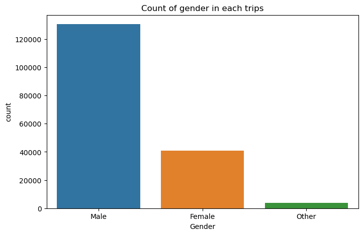

```python
bar_catg("member_gender",df.member_gender.value_counts().index, 'Count of gender in each trips','Gender')
```

> In general Men use bikes more than Female

### 2- What is the distribution of trips in the week?

```python
week_order=["Monday", "Tuesday", "Wednesday", "Thursday","Friday","Saturday","Sunday"]
```

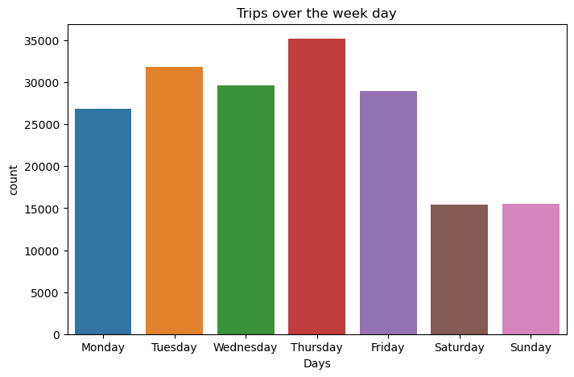

```python
bar_catg('day_of_week',week_order,'Trips over the week day','Days',)
```

> In general most trips occur on Thursday , and equally on Sunday and Saturday

### 3- What is the distribution of users in the dataset?

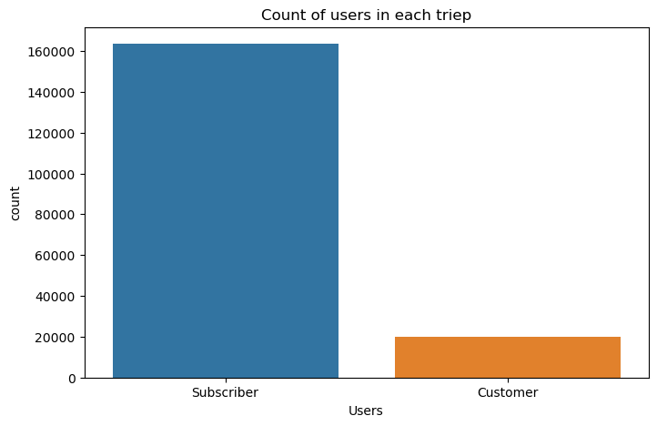

```python
bar_catg("user_type",df.user_type.value_counts().index, 'Count of users in each triep','Users')
```

> Majority of users of the biking system are subscribed, which is a good sign for the business

### 4- What is the distribution of trips in hours per day?

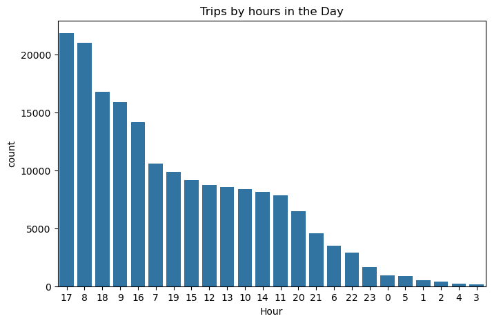

```python
# plot distribution of hours of week
plt.figure(figsize=[8, 5])
sb.countplot(data = df, x = 'start_hour', color =sb.color_palette()[0],order=df['start_hour'].value_counts().index)
plt.title('Trips by hours in the Day')
plt.xlabel('Hour')
plt.show()
```

> Majority of trips started at 17 which equals 5 pm and 8 am, this is reasonable because both times are related to the work hours. Conversely, 12 to 5 AM is the least time-demanding of bikes since it is late in the day.

### 5- What is the distribution of user's age in dataset?

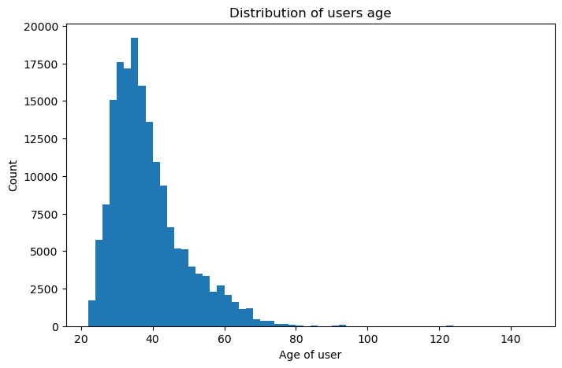

```python
bins = np.arange(df.age.min(), df.age.max()+2,2)
plt.figure(figsize=[8, 5])
plt.hist(data = df, x = 'age', bins=bins)
plt.xlabel('Age of user')
plt.ylabel('Count')
plt.title('Distribution of users age')
plt.show();
```

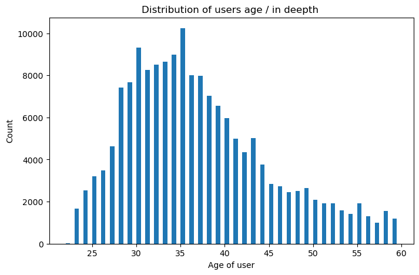

```python
# The age of the user in the tailed side( between 20-60 )
bins = np.arange(22,60,0.5)
plt.figure(figsize=[8, 5])
plt.hist(data = df, x = 'age', bins=bins)
plt.xlabel('Age of user')
plt.ylabel('Count')
plt.title('Distribution of users age / in deepth ')
plt.show();
```

> Most biking users are younger people, they are between 25 to 60, but also there is a good amount of older people who use bikes These people are the outliers in Age in the dataset such as 140 years

### 6- What is duration of trips in second , hours, minues?

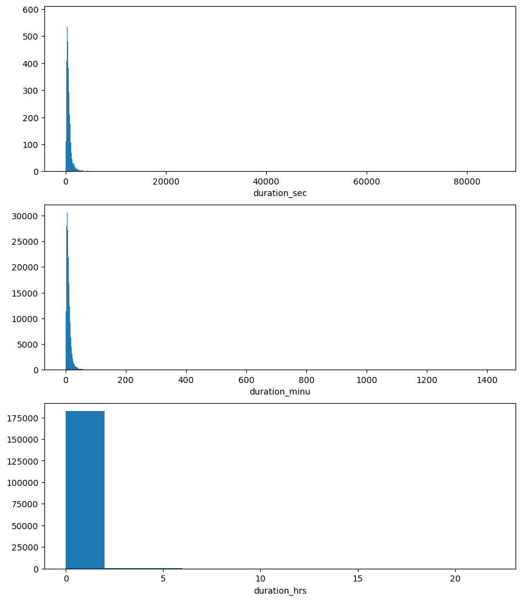

```python
# let's show the duration of each trip in sec, min , hrs  with x, y, and z.
fig, a = plt.subplots(nrows=3, figsize = [10,12])
duration = ['duration_sec', 'duration_minu', 'duration_hrs']
for x in range(len(duration)):
    var = duration[x]
    bins = np.arange(min(df[var]), max(df[var]),2)
    a[x].hist(data = df, x = var, bins = bins)
    a[x].set_xlabel('{}'.format(var))

plt.show()
```

### What is the duration in seconds , minutes, houres for each trips -close view?

### Seconds

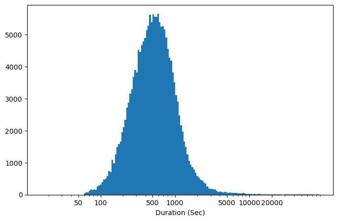

```python
# To take a real look with all data we use log scale and it shows that the 700 is the avrage
plt.figure(figsize=[8, 5])
bins = 10 ** np.arange(1.2, np.log10(df['duration_sec'].max())+0.022, 0.022)
plt.hist(data = df, x = 'duration_sec', bins=bins)
plt.xscale('log')
plt.xticks([50, 100, 500, 1000, 5000, 10000, 20000], [50, 100, 500, 1000, 5000, 10000, 20000])
plt.xlabel('Duration (Sec)');
```

```python
print(" Avrage Minutes :" , df['duration_minu'].mean(),'|', " Avrage Hours :", df['duration_hrs'].mean())
```

```
 Avrage Minutes : 11.60939306043225 |  Avrage Hours : 0.026285084945368898
```

### Minutes

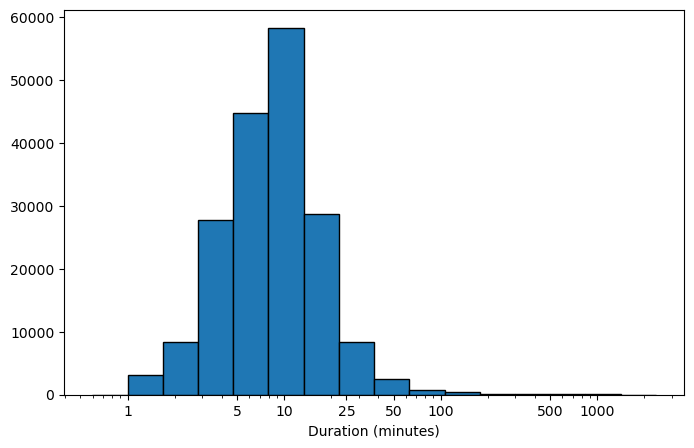

```python
plt.figure(figsize=[8, 5])
bins = 10 ** np.arange(np.log10(df['duration_minu'].min())-0.225, np.log10(df['duration_minu'].max())+0.225, 0.225)
plt.hist(data = df, x = 'duration_minu', bins=bins,edgecolor="black")
plt.xscale('log')
plt.xticks([1, 5,10,25,50,100,500, 1000], [1, 5,10,25,50,100,500, 1000])
plt.xlabel('Duration (minutes)');
```

### Hours

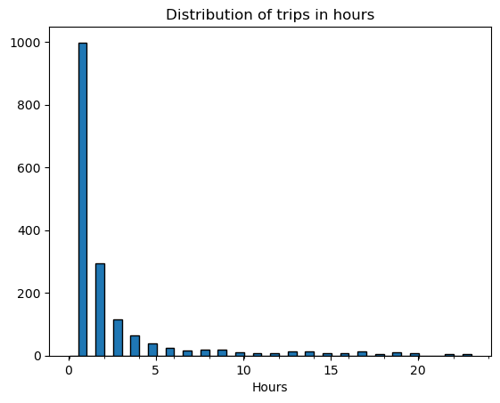

```python
### This to show the houres with overview
bins = np.arange(0.05,(df.duration_hrs.max()) + 0.5, 0.5)
plt.hist(data = df, x = 'duration_hrs', bins = bins,edgecolor="black")
plt.title('Distribution of trips in hours')
plt.xlabel('Hours')
plt.gca().set_xticks(np.arange(0.05, (df.duration_hrs.max())+2, 2), minor = True)
plt.show()
```

> From the figures, most durations of trips fall into 600 seconds or 12 minutes and they less than hour (around 45 minutes and 4 hrs)

### 7- What is the top stations?

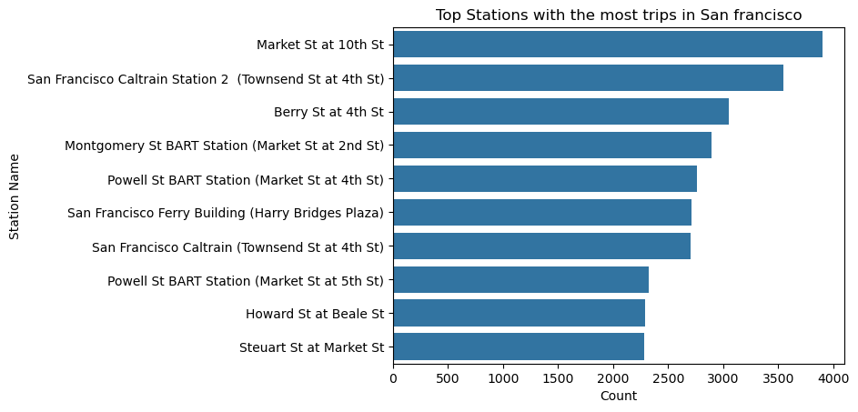

```python
## I choose the start station because the end station chooses mostly because it is near to their houses or more customers, not subscribers used it.
sb.countplot(data=df, y='start_station_name', color=sb.color_palette()[0], order=df['start_station_name'].value_counts().head(10).index)
plt.xlabel('Count')
plt.ylabel('Station Name')
plt.title('Top Stations with the most trips in San francisco');
```

> Most bikers start the trips at Market St at 10th St, and San Francisco Caltrain Station 2 (Townsend St at 4th St). We have to investigate more why there are most users there, maybe because they are in the center of the city and close to workplaces, or they are a nice place. This is one of the limitations, that we don't have enough data related to location

### 8- What is the age distribution for each gender?

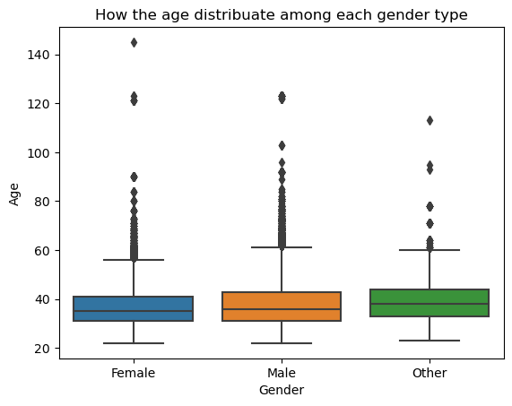

```python
sb.boxplot(data=df,x = "member_gender", y = "age")
plt.xlabel('Gender')
plt.ylabel('Age')
plt.title("How the age distribuate among each gender type")
plt.show()
```

> As shown above, most of female are young comparing to male. Will this effect the trip duration for each gender?

### 9- What is the average minutes that each gender spends on one trip?

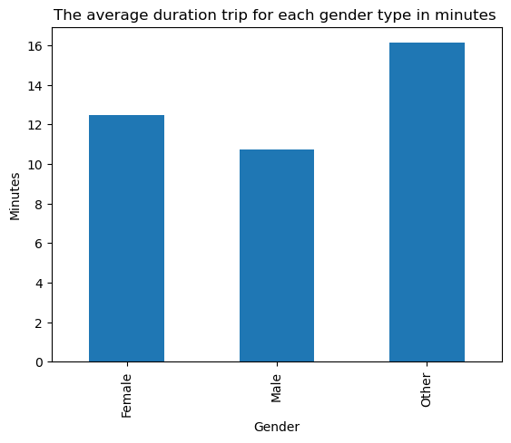

```python
df.groupby('member_gender')['duration_minu'].mean().plot(kind='bar')
plt.xlabel('Gender')
plt.ylabel('Minutes')
plt.title("The average duration trip for each gender type in minutes ")
plt.show()
```

> As we expected female able to spend more minutes in one trip.

### 10- What is the age distribution for each user type?

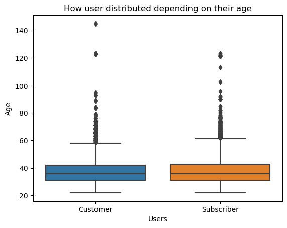

```python
sb.boxplot(data= df, x = "user_type", y='age')
plt.xlabel('Users')
plt.ylabel('Age')
plt.title("How user distributed depending on their age")
plt.show()
```

> As shown above, most of our subscriber is young, however, there are quite a few older people who are subscribed, and this impressive because we did not expect to have older people constantly using the biking system due to their health.

### 11- How much does each user spend in one trip ( user and duration)?

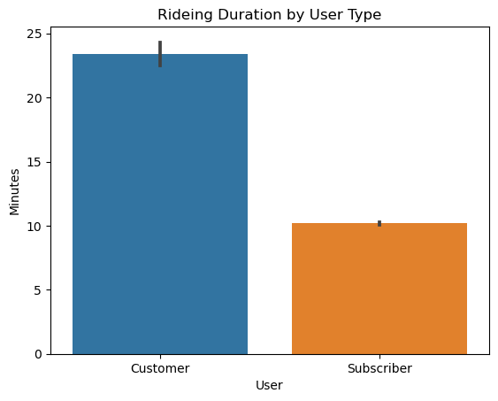

```python
plt.title('Rideing Duration by User Type')
sb.barplot(data=df, x='user_type', y='duration_minu')
plt.xlabel('User')
plt.ylabel('Minutes')
plt.show();
```

> Due to the fact that customers use it only once, they go on a longer trip than subscribers

### 12- When is the peak time for both subscribers and customers in one day?

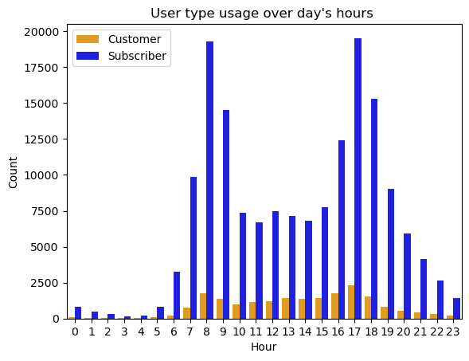

```python
x = sb.countplot(x=df.start_hour, hue=df.user_type,data=df, palette=['orange',"blue"])
x.set_title("User type usage over day's hours ")
plt.xlabel('Hour')
plt.ylabel('Count')
plt.legend(labels = ['Customer', 'Subscriber'])
plt.show()
```

> Most of the customers and subscribers use bikes at the same time so this means there are high demands at 17 or 8 . so we have to provide more at these hours.Also,customers may have more flexible time, generally between noon and 3 p.m so they use it more during this period.

### 13- How much does each age spend in one trip ( age and duration)?

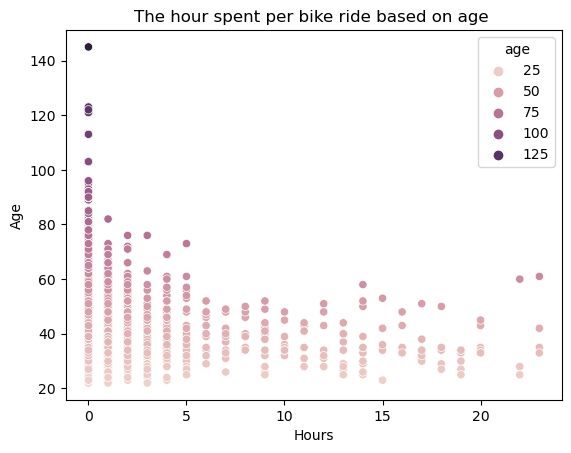

```python
sb.scatterplot(data=df, x="duration_hrs", y="age",hue= "age")
plt.xlabel('Hours')
plt.ylabel('Age')
plt.title('The hour spent per bike ride based on age ')
plt.show()
```

### 14 -Which day of the week is the most visited by each gender?

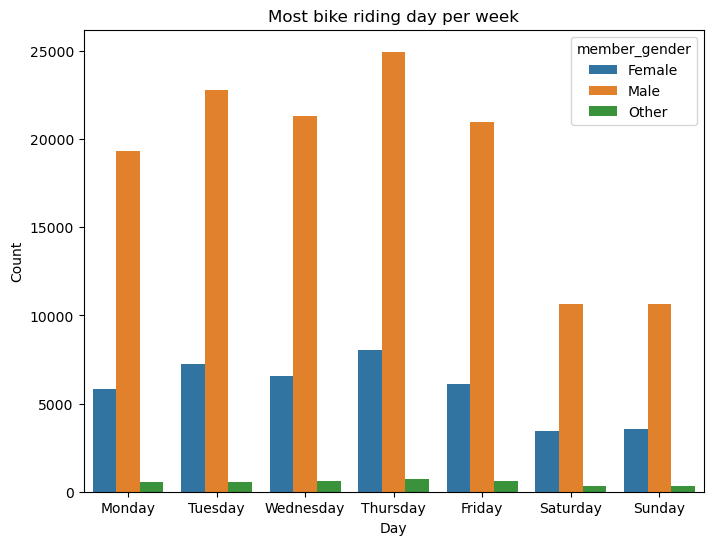

```python
plt.figure(figsize=(8,6))
plt.title('Most bike riding day per week')
sb.countplot(data=df, x='day_of_week',  hue='member_gender',order=week_order)
plt.xlabel('Day')
plt.ylabel('Count')
plt.show();
```

> Both male and famel have same pattern of used
> - Both females and males use bikes more on Thursday and less on Saturday

### 15- Which day of the week is the most used bike on, for each user?

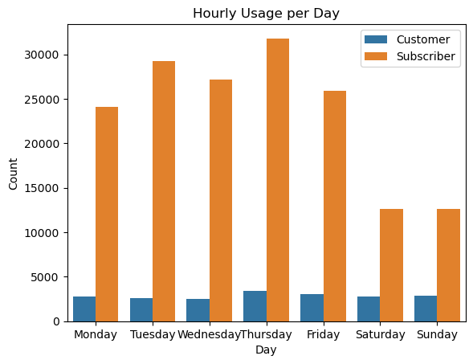

```python
plt.title('Hourly Usage per Day')
sb.countplot(data=df, x="day_of_week", hue='user_type',order = week_order)
plt.xlabel('Day')
plt.ylabel('Count')
plt.legend(labels = ['Customer', 'Subscriber'])
plt.figure(figsize=(12,8))
```

> Customers use bikes in almost the same pattern during the week, while subscribers use them more on Thursday and less on both weekends Sunday and Saturday. This shows that the more constantly the user used a bike or subscribed to the bike system the more it will be part of its lifestyle, so using it more for work and less on weekend

### Did you observe any interesting relationships between the other features (not the main feature(s) of interest)?

> The female bikers are younger than the male and i assume they are healthier so they take a long time on each trip and this was true.

## Multivariate Exploration

> The main thing I want to explore in this part of the analysis is how user behavier dusring week regarding hour of biking or duration for each trip.

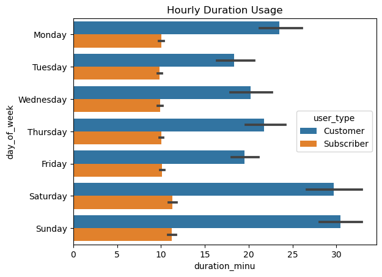

```python
plt.title('Hourly Duration Usage')
sb.barplot(data=df, x='duration_minu', y='day_of_week', hue='user_type',order=week_order)
```

> Most customers spend more 20 minutes on sunday and saturday (weekend), and we can see change on the pattern for subscribers during weekend as well by slightly increaseing

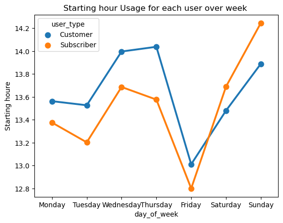

```python
x = df.groupby(['user_type','day_of_week']).start_hour.mean().reset_index()
sb.pointplot(data = x, x='day_of_week', y='start_hour', hue='user_type',order=week_order)
plt.title("Starting hour Usage for each user over week ")
plt.ylabel('Starting houre');
```

> To dig deeper I want to see when they spend most time biking during the weekend because we know most of them use the bike during the workdays either at the end of the day 4-5 PM or 7-9 AM start work hour

```python
#Filter dataset depend on the days
weekend= df[(df["day_of_week"]=='Saturday') | (df["day_of_week"]=='Sunday')]
workday= df[~df["day_of_week"].isin(weekend)]
```

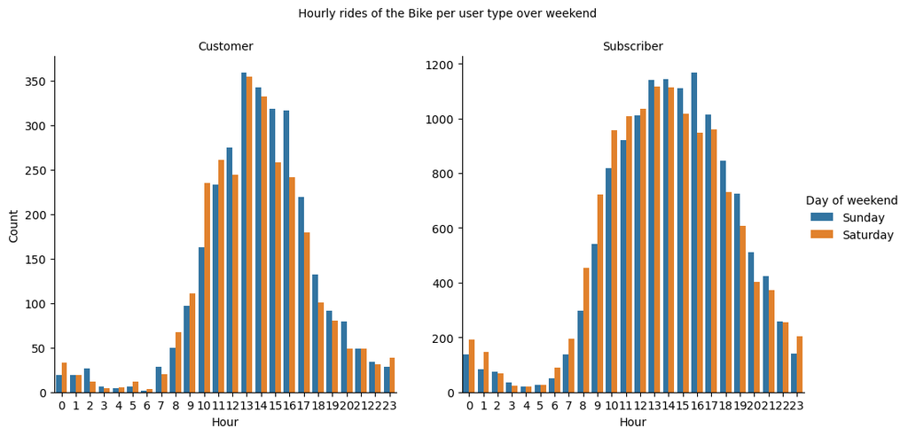

```python
# Plot only the weekend
weekend_hour= sb.catplot(data=weekend, x='start_hour', col='user_type', hue='day_of_week', kind='count', sharey = False)
weekend_hour.set_axis_labels("Hour", "Count")
weekend_hour._legend.set_title('Day of weekend')
weekend_hour.set_titles("{col_name}")
weekend_hour.fig.suptitle('Hourly rides of the Bike per user type over weekend',fontsize=10,y=1.05);
```

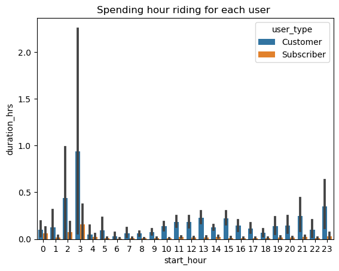

```python
plt.title("Spending hour riding for each user ")
sb.barplot(data=df, x='start_hour',y='duration_hrs',hue='user_type')
```

## Conclusions

> At the end of this I observed many things related to the usage pattern For instance: we can increase profit if we focus on males because they are more than females in the dataset, also if we provided along with bike some comfortable stuff will attract more female since they bike for a long time.